# Multiple Linear Regression

### 1.3.2 Multicollinearity

Are the variables correlated? If the VIF score > 10 then there is multicollinearity.

```r
mod <- lm(mpg ~ hp + wt, data = mtcars)

# checking the VIF of both predictors
vif(mod)
  hp   wt
1.77 1.77

# checking the correlation between the predictors
cor(mtcars$hp, mtcars$wt)
[1] 0.659
```

### 1.3.3 Homoscedasticity

Checking the residual plots for homoscedasticity. The line below is relatively horizontal.

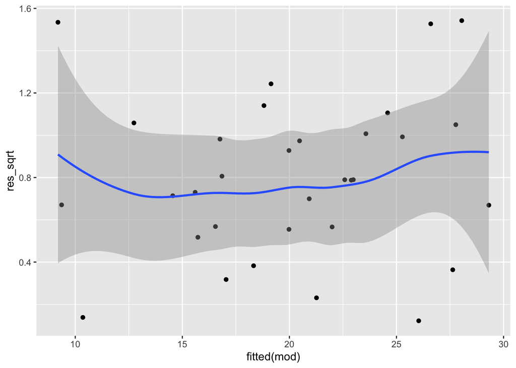

```r
mtcars_df <- mtcars %>%
  mutate(res_sqrt = sqrt(abs(rstandard(mod))))

ggplot(mtcars_df, aes(fitted(mod), res_sqrt)) +
  geom_point() +
  geom_smooth()
```

### 1.3.4 Normality

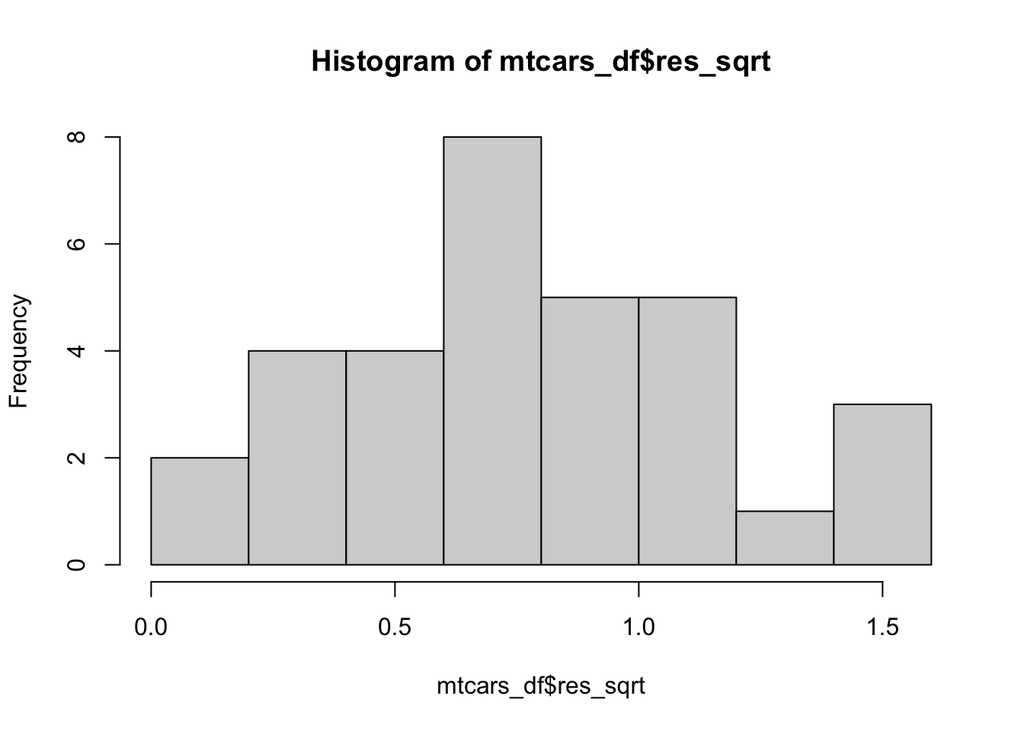

```r
# histogram
hist(mtcars_df$res_sqrt)
```

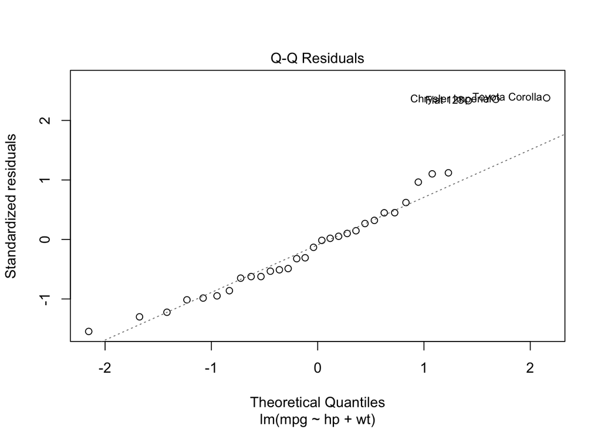

```r
# qq plot
plot(mod, 2)
```

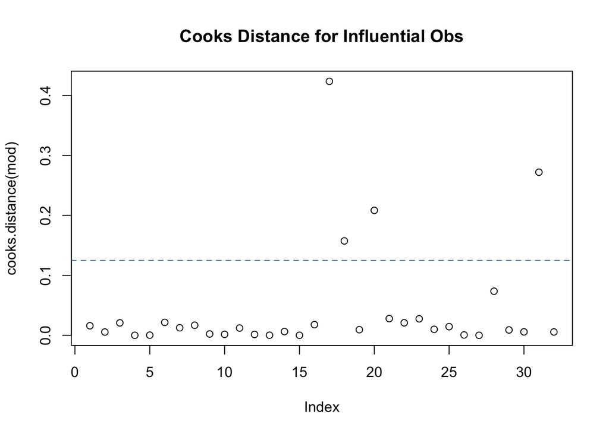

```r
# cook's d -> are the outliers in the qq plot driving the relationship in the model?
cooks.distance(mod)
          Mazda RX4       Mazda RX4 Wag          Datsun 710      Hornet 4 Drive
           1.59e-02            5.46e-03            2.07e-02            4.72e-05
  Hornet Sportabout             Valiant          Duster 360           Merc 240D
           2.74e-04            2.16e-02            1.26e-02            1.68e-02
           Merc 230            Merc 280           Merc 280C          Merc 450SE
           2.19e-03            1.55e-03            1.22e-02            1.42e-03
         Merc 450SL         Merc 450SLC  Cadillac Fleetwood Lincoln Continental
           1.46e-04            6.27e-03            2.79e-05            1.78e-02
  Chrysler Imperial            Fiat 128         Honda Civic      Toyota Corolla
           4.24e-01            1.57e-01            9.37e-03            2.08e-01
      Toyota Corona    Dodge Challenger         AMC Javelin          Camaro Z28
           2.79e-02            2.09e-02            2.75e-02            9.94e-03
   Pontiac Firebird           Fiat X1-9       Porsche 914-2        Lotus Europa
           1.44e-02            5.92e-04            5.67e-06            7.35e-02
     Ford Pantera L        Ferrari Dino       Maserati Bora          Volvo 142E
           8.92e-03            5.73e-03            2.72e-01            5.60e-03

# Plot Cook's Distance with a horizontal line at 4/n to see which observations
# exceed this thresdhold
n <- nrow(mtcars)
plot(cooks.distance(mod), main = "Cooks Distance for Influential Obs")
abline(h = 4/n, lty = 2, col = "steelblue")
```

Cook’s distance refers to how far, on average, predicted y-values will move if the observation in question is dropped from the data set.

Since there are very few extreme values according to cook’s d values, we can assume they are not the driving force between the relationship of the predictor and outcome.

Tentative model:

mpg = $b_0$ + $b_1\times$horsepower + $b_2\times$weight + $\epsilon$

## 1.4 Hypothesis Testing

Does the horsepower and weight of a car contribute significantly to the miles per gallon of the car?

- What is the relationship between horsepower and weight, with miles per gallon of the car?-

$$H_0: \beta_1 = \beta_2 = 0$$

$$H_1: \beta_1 \not= \beta_2 \not= 0$$

```r
car_model <- lm(mpg ~ hp + wt, data = mtcars_df)

# get the F statistic and p-value
summary(car_model)

Call:
lm(formula = mpg ~ hp + wt, data = mtcars_df)

Residuals:
   Min     1Q Median     3Q    Max
-3.941 -1.600 -0.182  1.050  5.854

Coefficients:
            Estimate Std. Error t value Pr(>|t|)
(Intercept) 37.22727    1.59879   23.28  < 2e-16 ***
hp          -0.03177    0.00903   -3.52   0.0015 **
wt          -3.87783    0.63273   -6.13  1.1e-06 ***
---
Signif. codes:  0 '***' 0.001 '**' 0.01 '*' 0.05 '.' 0.1 ' ' 1

Residual standard error: 2.59 on 29 degrees of freedom
Multiple R-squared:  0.827, Adjusted R-squared:  0.815
F-statistic: 69.2 on 2 and 29 DF,  p-value: 9.11e-12

# creating a table of the model
car_model %>%
  tidy() %>%
  gt()
```

| term | estimate | std.error | statistic | p.value |
| --- | --- | --- | --- | --- |
| (Intercept) | 37.2273 | 1.59879 | 23.28 | 2.57e-20 |
| hp | -0.0318 | 0.00903 | -3.52 | 1.45e-03 |
| wt | -3.8778 | 0.63273 | -6.13 | 1.12e-06 |

The first step in interpreting the multiple regression analysis is to examine the F-statistic and the associated p-value, at the bottom of model summary.

In our example, it can be seen that p-value of the F-statistic is < 9.109e-12, which is less than 0.05. This means that we can reject the null and accept that either horsepower and/or weight of a car predict the miles per gallon.

To see which predictor variables are significant, we can examine the coefficients table, which shows the estimate and the associated t-statistic p-values:

```r
summary(car_model)$coefficient
            Estimate Std. Error t value Pr(>|t|)
(Intercept)  37.2273    1.59879   23.28 2.57e-20
hp           -0.0318    0.00903   -3.52 1.45e-03
wt           -3.8778    0.63273   -6.13 1.12e-06

summary(car_model)$coefficient %>%
  as_tibble() %>%
  add_column(Variable = c("Intercept", "Horsepower", "Weight"), .before = "Estimate") %>%
  gt()
```

| Variable | Estimate | Std. Error | t value | Pr(>\|t\|) |
| --- | --- | --- | --- | --- |
| Intercept | 37.2273 | 1.59879 | 23.28 | 2.57e-20 |
| Horsepower | -0.0318 | 0.00903 | -3.52 | 1.45e-03 |
| Weight | -3.8778 | 0.63273 | -6.13 | 1.12e-06 |

Full model: mpg = 37.23 + (-0.03)$\times$horsepower + (-3.88)$\times$weight

For a given predictor, the t-statistic value evaluates whether or not there is significant association between the predictor and the outcome variable, that is whether the beta coefficient of the predictor is significantly different from zero.

It can be seen that horsepower and weight are significantly associated to changes in mpg.

```r
# The confidence interval of the model
confint(car_model)
              2.5 %  97.5 %
(Intercept) 33.9574 40.4972
hp          -0.0502 -0.0133
wt          -5.1719 -2.5837

confint(car_model) %>%
  as_tibble() %>%
  add_column(Variable = c("Intercept", "Horsepower", "Weight"), .before = "2.5 %") %>%
  gt()
```

| Variable | 2.5 % | 97.5 % |
| --- | --- | --- |
| Intercept | 33.9574 | 40.4972 |
| Horsepower | -0.0502 | -0.0133 |
| Weight | -5.1719 | -2.5837 |

## 1.5 Likelihood Ratio Test

$H_0$: The full model and the nested model fit the data equally well. Thus, you should use the nested model.

$H_1$: The full model fits the data significantly better than the nested model. Thus, you should use the full model.

A likelihood ratio test compares the goodness of fit of two nested regression models.

A nested model is simply one that contains a subset of the predictor variables in the overall regression model.

We could then carry out another likelihood ratio test to determine if a model with only one predictor variable is significantly different from a model with the two predictors:

```r
#fit full model
model_full <- lm(mpg ~ hp + wt, data = mtcars)

#fit reduced model
model_reduced <- lm(mpg ~ hp, data = mtcars)

#perform likelihood ratio test for differences in models
lrtest(model_full, model_reduced)
Likelihood ratio test

Model 1: mpg ~ hp + wt
Model 2: mpg ~ hp
  #Df LogLik Df Chisq Pr(>Chisq)
1   4  -74.3
2   3  -87.6 -1  26.6    2.5e-07 ***
---
Signif. codes:  0 '***' 0.001 '**' 0.01 '*' 0.05 '.' 0.1 ' ' 1

#fit reduced model
model_reduced <- lm(mpg ~ wt, data = mtcars)

#perform likelihood ratio test for differences in models
lrtest(model_full, model_reduced)
Likelihood ratio test

Model 1: mpg ~ hp + wt
Model 2: mpg ~ wt
  #Df LogLik Df Chisq Pr(>Chisq)
1   4  -74.3
2   3  -80.0 -1  11.4    0.00074 ***
---
Signif. codes:  0 '***' 0.001 '**' 0.01 '*' 0.05 '.' 0.1 ' ' 1
```

Our p-values are less than 0.05 for both Chi-squared values, suggesting that the full model offers significant improvement in fit over the model with just one of the predictors.

## 1.6 Model Accuracy

In multiple linear regression, the $R^2$ represents the correlation coefficient between the observed values of the outcome variable (y) and the fitted (i.e., predicted) values of y. For this reason, the value of R will always be positive and will range from zero to one.

An $R^2$ value close to 1 indicates that the model explains a large portion of the variance in the outcome variable.

```r
summary(car_model)$adj.r.squared %>%
  as_tibble() %>%
  rename("Adjusted R Squared" = value) %>%
  gt()
```

| Adjusted R Squared |
| --- |
| 0.815 |

Our model explains 81% of the variation in mpg values caused by horsepower and weight values.

# 2 Conclusion

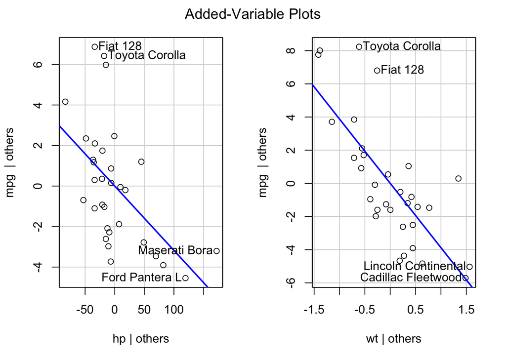

```r
avPlots(car_model)
```

For multiple linear regression, there are multiple independent variables affecting the outcome. This outcome must be continuous, however, the independent variables can be numeric or categorical.

There is an inverse or negative relationship between our predictors and outcome variable. The mpg decreases with heavier weight. Higher horsepower also reduces miles per gallon performance (higher fuel consumption).